# The excluderanges and nullranges packages

Mario Keller

Faculty of Biological Sciences, Goethe University Frankfurt

14 June 2022

```r
library(dplyr)
library(tidyr)
library(ggplot2)
library(knitr)

library(viridis)
library(ggpubr)
library(ggsci)
library(ggbeeswarm)

library(GenomicRanges)
library(rtracklayer)
library(GenomicFeatures)
library(BSgenome.Hsapiens.UCSC.hg38)
```

```r
myTheme <- theme_bw() +
    theme(axis.text = element_text(size = 14, colour="black"),
          axis.title = element_text(size=16, colour="black"),
          axis.ticks=element_line(color="black"),
          axis.ticks.length=unit(.15, "cm"),
          panel.border=element_rect(color="black", fill = NA),
          panel.background = element_blank(),
          plot.background = element_blank(),
          legend.text = element_text(size=12),
          legend.position = "none")
```

# 1 Introduction

When dealing with data from high-throughput experiments there are certain genomic regions that have anomalous, unstructured, or high signal in next-generation sequencing experiments independent of cell line or experiment[^1]. These so-called blacklist regions should be removed right in the beginning of your analysis to prevent false conclusions from your data. BED-files of blacklist regions are available on the [ENCODE project website](https://www.encodeproject.org/search/?searchTerm=exclusion+list). The *excluderanges*[^2] package enables user-friendly access to blacklist regions from different resources that are stored as GRanges objects. The user can easily remove ranges from his/her GRagens object overlapping the loaded blacklist regions.

A second problem we often encounter is the definition of control ranges we want to compare our ranges of interest against. For instance, we might have a set of differentially regulated introns we want to compare a set control set of non-regulated introns but want to make sure that the length distribution of the introns is the same. Another example is Mirko’s famous PSI-matching approach in the context of RNAmaps where we want to have a control set of non-regulated alternative splicing events with an equal distribution of PSI values. The *nullranges*[^3] package enables this matching task under the consideration of one or multiple covariates (e.g intron length or PSI values).

# 2 excluderanges

## 2.1 Datasets

The dataset I use for the excluderanges section are double-strand break hotspots (DSBhotspots) from HCT116 cells that are loaded from a MAC2 XLS-File and subsequently transfered into a GRanges object.

```r
DSBhotspots <- read.table("/Users/mariokeller/projects/Vassilis/data/sBLISS_HCT116/imb_roukos_2020_07_10_longo_hct116_std_dox_2_hct116stddox2_CGTGTGAG_chr-loc-countDifferentUMI.bed_peaks.hg38.xls", header=TRUE, sep="\t")
DSBhotspots <- DSBhotspots[!((DSBhotspots$name %>% duplicated()) | (DSBhotspots$name %>% duplicated(., fromLast=TRUE))),]

chromosomes = paste0("chr",c(1:22, "X", "Y"))
DSBhotspots <- makeGRangesFromDataFrame(DSBhotspots, keep.extra.columns = TRUE)
DSBhotspots <- DSBhotspots[seqnames(DSBhotspots) %in% chromosomes]
seqlevels(DSBhotspots) <- chromosomes
DSBhotspots <- keepSeqlevels(DSBhotspots, chromosomes, pruning.mode = "coarse")
head(DSBhotspots)
```

```
## GRanges object with 6 ranges and 7 metadata columns:
##     seqnames          ranges strand |    length abs_summit    pileup
##        <Rle>       <IRanges>  <Rle> | <integer>  <integer> <integer>
##   1     chr1   926095-926341      * |       247     861576        13
##   2     chr1   940811-941078      * |       268     876263        14
##   3     chr1   975632-975844      * |       213     911084        17
##   4     chr1 1000688-1000925      * |       238     936248        27
##   5     chr1 1006563-1006922      * |       360     942114        34
##   6     chr1 1013178-1013380      * |       203     948743        19
##     X.log10.pvalue. fold_enrichment X.log10.qvalue.                   name
##           <numeric>       <numeric>       <numeric>            <character>
##   1         7.53305         4.66667         4.71333 imb_roukos_2020_07_1..
##   2         6.50438         3.92670         3.78591 imb_roukos_2020_07_1..
##   3         9.72299         5.17241         6.72208 imb_roukos_2020_07_1..
##   4        14.78436         5.80913        11.43968 imb_roukos_2020_07_1..
##   5        26.80566         9.83146        22.89428 imb_roukos_2020_07_1..
##   6         8.24351         4.11523         5.36483 imb_roukos_2020_07_1..
##   -------
##   seqinfo: 24 sequences from an unspecified genome; no seqlengths
```

## 2.2 Removal of hotspots overlapping blacklist regions

We can access the blacklist regions via the AnnotationHub package using the query() function and setting “excluderanges” as second parameter. Let’s print the overview to see what is available.

```r
suppressMessages(library(AnnotationHub))
ah <- AnnotationHub()
query_data <- query(ah, "excluderanges")
query_data
```

```
## AnnotationHub with 42 records
## # snapshotDate(): 2021-10-20
## # $dataprovider: UCSC, ENCODE, mitra.stanford.edu/kundaje/akundaje/release/b...
## # $species: Homo sapiens, Mus musculus, Drosophila melanogaster, Caenorhabdi...
## # $rdataclass: GRanges
## # additional mcols(): taxonomyid, genome, description,
## #   coordinate_1_based, maintainer, rdatadateadded, preparerclass, tags,
## #   rdatapath, sourceurl, sourcetype
## # retrieve records with, e.g., 'object[["AH95908"]]'
##
##             title
##   AH95908 | ce10.Kundaje.ce10-Excludable.rds
##   AH95909 | dm3.Kundaje.dm3-Excludable.rds
##   AH95910 | hg19.Bernstein.Mint_Excludable_hg19.rds
##   AH95911 | hg19.Birney.wgEncodeDacMapabilityConsensusExcludable.rds
##   AH95912 | hg19.Crawford.wgEncodeDukeMapabilityRegionsExcludable.rds
##   ...       ...
##   AH95945 | mm10.UCSC.telomere.rds
##   AH95946 | mm9.UCSC.centromere.rds
##   AH95947 | mm9.UCSC.contig.rds
##   AH95948 | mm9.UCSC.fragment.rds
##   AH95949 | mm10.UCSC.scaffold.rds
```

We can see that there are 42 records available that belong to four different model organisms.

The blacklist regions can be downloaded as GRanges objects by subsetting the query_data object using the identifier (e.g. query_data[[“AH95917”]]). What we do is downloading blacklists from 6 available ENCODE resources and combining them into a single GRanges object using reduce().

```r
excludeGR.hg38.Bernstein <- query_data[["AH95915"]]
excludeGR.hg38.Kundaje.2 <- query_data[["AH95916"]]
excludeGR.hg38.Kundaje.1 <- query_data[["AH95917"]]
excludeGR.hg38.Reddy     <- query_data[["AH95918"]]
excludeGR.hg38.Wold      <- query_data[["AH95919"]]
excludeGR.hg38.Yeo       <- query_data[["AH95920"]]
excludeGR.hg38.all <- reduce(c(excludeGR.hg38.Bernstein, excludeGR.hg38.Kundaje.1, excludeGR.hg38.Kundaje.2, excludeGR.hg38.Reddy, excludeGR.hg38.Wold, excludeGR.hg38.Yeo))
```

In total, we have 13,244 regions covering 107,972,970 bases.

We can also have a look on the length distribution of the blacklist regions.

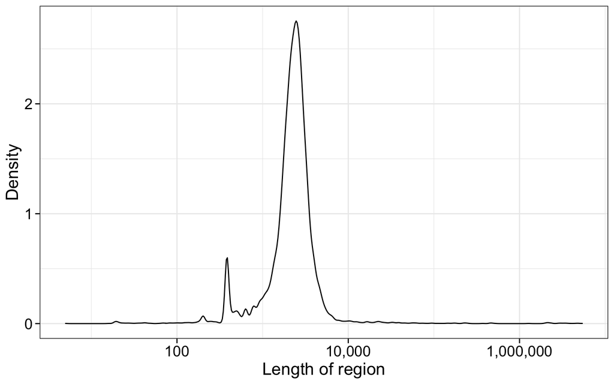

```r
width(excludeGR.hg38.all) %>% as.data.frame %>% dplyr::rename(., width=.) %>%
    ggplot(., aes(x=width)) +
    geom_density() +
    scale_x_log10(labels = scales::comma) +#scales::trans_format("log10", scales::math_format(10^.x))) +
    labs(x="Length of region", y="Density") +
    myTheme
```

We can see that the majority of blacklist regions has a length between 1 and 10 kilobases.

Now that we have the blacklist regions in a GRanges object, we can remove those DSBhotspots that overlap any of the blacklist regions using subsetByOverlaps() and setting invert=TRUE. Results are shown in the table.

```r
before <- length(DSBhotspots)

blDSBhotspots <- subsetByOverlaps(DSBhotspots, excludeGR.hg38.all)
DSBhotspots <- subsetByOverlaps(DSBhotspots, excludeGR.hg38.all, invert = TRUE)
after <- length(DSBhotspots)

data.frame(set="DSBhotspots", before=before, after=after) %>%
knitr::kable(., "html") %>% kableExtra::kable_styling("striped") %>% kableExtra::scroll_box(width = "100%")
```

| set | before | after |
| --- | --- | --- |
| DSBhotspots | 30693 | 30004 |

Here you can see an example of a DSBhotspot region that was removed due to an overlap with a blacklist region. As you can see the region with enriched sBLISS signal falls perfectly into the blacklist region. In addition, I added Repeat Masker tracks and we can see that the signal originates from a LSU-rRNA repeat.

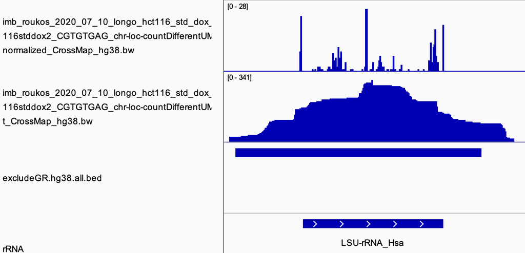

```r
knitr::include_graphics("/Users/mariokeller/projects/special_group_seminar/Screenshot 2022-06-14 at 13.18.36.png")
```

# 3 nullranges

## 3.1 Datasets

The datasets I use for the nullranges section are minigenes of regulated and non-regulated cassette exon events. In the beginning it is a GRangesList containing for each minigene 3 exons. For simplicity I reduce each minigene to a single region.

```r
regMiniGenes <- readRDS("/Users/mariokeller/projects/HNRNPH_project/new_2022/subprojects/3_iCLIP/rds/minigenesCEs.rds")
regMiniGenes <- regMiniGenes[lengths(regMiniGenes)==3]

nonRegMiniGenes <- readRDS("/Users/mariokeller/projects/HNRNPH_project/new_2022/subprojects/3_iCLIP/rds/nonregulatedMinigenesCEs.rds")
nonRegMiniGenes <- nonRegMiniGenes[lengths(nonRegMiniGenes)==3]


regMiniGenes <- lapply(regMiniGenes, function(gr){
  event_id <- gr$event_id %>% unique
  nH <- gr$nH %>% unique
  ec50 <- gr$ec50 %>% unique
  hillCat <- gr$hillCat %>% unique
  gr <- range(gr)
  gr$event_id <- event_id
  gr$nH <- nH
  gr$ec50 <- ec50
  gr$hillCat <- hillCat
  return(gr)
}) %>% as(., "GRangesList") %>% unlist
seqlevels(regMiniGenes) <- paste0("chr", c(1:22,"X","Y"))
seqlengths(regMiniGenes) <- seqlengths(Hsapiens)[1:24]


nonRegMiniGenes <- lapply(nonRegMiniGenes, function(gr){
  event_id <- gr$event_id %>% unique
  gr <- range(gr)
  gr$event_id <- event_id
  return(gr)
}) %>% as(., "GRangesList") %>% unlist
seqlevels(nonRegMiniGenes) <- paste0("chr", c(1:22,"X","Y"))
seqlengths(nonRegMiniGenes) <- seqlengths(Hsapiens)[1:24]

regCEs <- readRDS("/Users/mariokeller/projects/HNRNPH_project/new_2022/subprojects/1_MAJIQ/rds/regulatedCEs.rds")
regMiniGenes$PSI <- regCEs[match(names(regMiniGenes), regCEs$event_id),]$KD_Contr_median_psi


regMiniGenes <- regMiniGenes[regMiniGenes$hillCat=="Coop-Enh"]

nonRegCEs <- readRDS("/Users/mariokeller/projects/HNRNPH_project/new_2022/subprojects/1_MAJIQ/rds/nonregulatedCEs.rds")
nonRegMiniGenes$PSI <- nonRegCEs[match(names(nonRegMiniGenes), nonRegCEs$event_id),]$KD_Contr_median_psi

head(regMiniGenes)
```

```
## GRanges object with 6 ranges and 5 metadata columns:
##                             seqnames              ranges strand |
##                                <Rle>           <IRanges>  <Rle> |
##   ENSG00000001497.18_1_CE_1     chrX   65532561-65534572      - |
##   ENSG00000011258.16_6_CE_1    chr17   51201592-51202935      - |
##   ENSG00000036054.13_2_CE_1     chr3 100310403-100316187      + |
##   ENSG00000082641.16_4_CE_1    chr17   48056386-48057502      + |
##   ENSG00000100038.20_2_CE_1    chr22   21968619-21971951      - |
##   ENSG00000100325.15_2_CE_1    chr22   29825087-29832342      - |
##                                           event_id        nH      ec50
##                                        <character> <numeric> <numeric>
##   ENSG00000001497.18_1_CE_1 ENSG00000001497.18_1.. -19.10918   85.7783
##   ENSG00000011258.16_6_CE_1 ENSG00000011258.16_6..  -4.40175   30.7747
##   ENSG00000036054.13_2_CE_1 ENSG00000036054.13_2..  -4.45867   45.5855
##   ENSG00000082641.16_4_CE_1 ENSG00000082641.16_4..  -5.06840  113.8643
##   ENSG00000100038.20_2_CE_1 ENSG00000100038.20_2.. -29.47619   44.9523
##   ENSG00000100325.15_2_CE_1 ENSG00000100325.15_2.. -41.14133   45.6967
##                                 hillCat       PSI
##                             <character> <numeric>
##   ENSG00000001497.18_1_CE_1    Coop-Enh     0.957
##   ENSG00000011258.16_6_CE_1    Coop-Enh     0.947
##   ENSG00000036054.13_2_CE_1    Coop-Enh     0.322
##   ENSG00000082641.16_4_CE_1    Coop-Enh     0.300
##   ENSG00000100038.20_2_CE_1    Coop-Enh     0.808
##   ENSG00000100325.15_2_CE_1    Coop-Enh     0.845
##   -------
##   seqinfo: 24 sequences from an unspecified genome
```

## 3.2 Matching by PSI

As mentioned in the introduction the nullranges package enables the definition of matched control ranges. For our regulated cassette exon minigenes, we want to have a control set of non-regulated cassette exon minigenes with a similar PSI distribution (PSI values are in a meta-column of the GRanges objects).

For the matching process via matchRanges() three methods are available:

- method = ‘rejection’: (Default) Rejection sampling with or without replacement. Uses a probability-based approach to select options in the pool that match the focal distribution.
- method = ‘nearest’: Nearest neighbor matching with replacement. Finds the nearest neighbor by using a rolling join with data.table. Matching without replacement is not currently supported.
- method = ‘stratified’: Iterative stratified sampling with or without replacement. Bins focal and pool propensity scores by value and selects matches within bins until all focal items have a corresponding match in pool.

As the PSI distributions differ very much the default rejection method is not working. We will try three approaches: (i) the nearest method with replacement, (ii) stratified with replacement and (iii) stratified without replacement.

```r
library(nullranges)

names(regMiniGenes) <- c()
names(nonRegMiniGenes) <- c()

set.seed(123)
matchedNearest <- matchRanges(focal = regMiniGenes,
                   pool = nonRegMiniGenes,
                   covar = ~PSI,
                   method="nearest",
                   replace=T)

matchedStratifiedWithRepl <- matchRanges(focal = regMiniGenes,
                   pool = nonRegMiniGenes,
                   covar = ~PSI,
                   method="stratified",
                   replace=T)

matchedStratifiedWithoutRepl <- matchRanges(focal = regMiniGenes,
                   pool = nonRegMiniGenes,
                   covar = ~PSI,
                   method="stratified",
                   replace=F)
```

We will check the outcome by plotting the PSI distributions of the regulated minigenes, all non-regulated minigenes and the three matche sets.

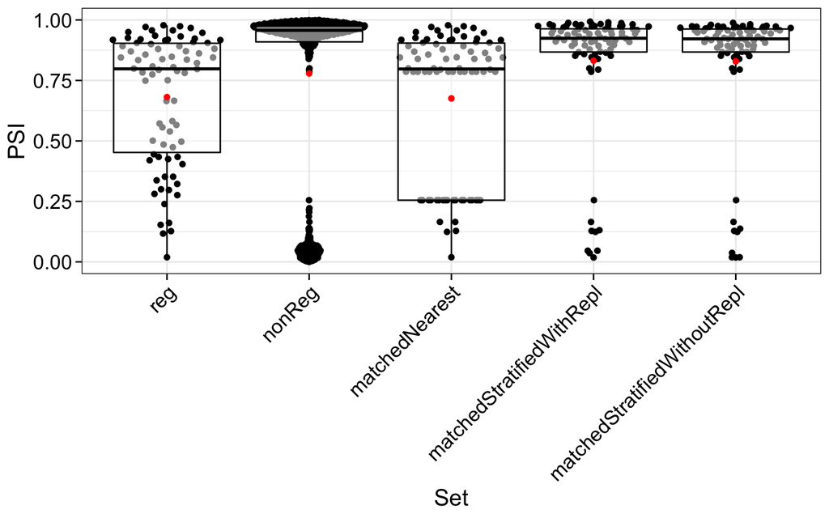

```r
data.frame(set=c(rep("reg", length(regMiniGenes)),
                 rep("nonReg", length(nonRegMiniGenes)),
                 rep("matchedNearest", length(matchedNearest)),
                 rep("matchedStratifiedWithRepl", length(matchedStratifiedWithRepl)),
                 rep("matchedStratifiedWithoutRepl", length(matchedStratifiedWithoutRepl))),
           PSI=c(regMiniGenes$PSI, nonRegMiniGenes$PSI, matchedNearest$PSI, matchedStratifiedWithRepl$PSI, matchedStratifiedWithoutRepl$PSI)) %>%
    mutate(set=factor(set, levels=c("reg", "nonReg", "matchedNearest", "matchedStratifiedWithRepl", "matchedStratifiedWithoutRepl"))) %>%
    ggplot(., aes(x=set, y=PSI)) +
        geom_quasirandom() +
        geom_boxplot(alpha=.5, outlier.size = -1, col="black") +
        stat_summary(fun.y="mean", geom="point", col="red") +
        labs(x="Set", y="PSI") +
        myTheme +
        theme(axis.text.x = element_text(angle=45, vjust=1, hjust=1))
```

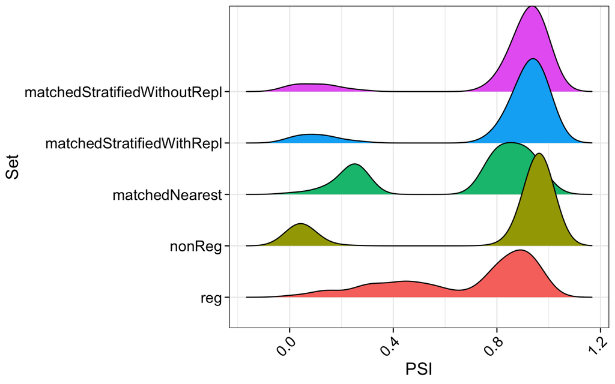

```r
data.frame(set=c(rep("reg", length(regMiniGenes)),
                 rep("nonReg", length(nonRegMiniGenes)),
                 rep("matchedNearest", length(matchedNearest)),
                 rep("matchedStratifiedWithRepl", length(matchedStratifiedWithRepl)),
                 rep("matchedStratifiedWithoutRepl", length(matchedStratifiedWithoutRepl))),
           PSI=c(regMiniGenes$PSI, nonRegMiniGenes$PSI, matchedNearest$PSI, matchedStratifiedWithRepl$PSI, matchedStratifiedWithoutRepl$PSI)) %>%
    mutate(set=factor(set, levels=c("reg", "nonReg", "matchedNearest", "matchedStratifiedWithRepl", "matchedStratifiedWithoutRepl"))) %>%
    ggplot(., aes(x=PSI, y=set, fill=set)) +
        ggridges::geom_density_ridges() +
        labs(x="PSI", y="Set") +
        myTheme +
        theme(axis.text.x = element_text(angle=45, vjust=1, hjust=1))
```

As we can see the matching does not work perfectly as the distributions of the regulated and non-regulated minigenes are extremely different.

## 3.3 Matching by length

In a different scenario we might be interested in picking a control set of non-regulated minigenes with a similar length distribution. Now we can also use the rejection method with and without replacement.

```r
regMiniGenes$length <- width(regMiniGenes)
nonRegMiniGenes$length <- width(nonRegMiniGenes)

set.seed(123)
matchedRejectionWithRepl <- matchRanges(focal = regMiniGenes,
                   pool = nonRegMiniGenes,
                   covar = ~length,
                   method="rejection",
                   replace=T)

matchedRejectionWithoutRepl <- matchRanges(focal = regMiniGenes,
                   pool = nonRegMiniGenes,
                   covar = ~length,
                   method="rejection",
                   replace=F)

matchedNearest <- matchRanges(focal = regMiniGenes,
                   pool = nonRegMiniGenes,
                   covar = ~length,
                   method="nearest",
                   replace=T)

matchedStratifiedWithRepl <- matchRanges(focal = regMiniGenes,
                   pool = nonRegMiniGenes,
                   covar = ~length,
                   method="stratified",
                   replace=T)

matchedStratifiedWithoutRepl <- matchRanges(focal = regMiniGenes,
                   pool = nonRegMiniGenes,
                   covar = ~length,
                   method="stratified",
                   replace=F)
```

We will check the outcome by plotting the length distributions of the regulated minigenes, all non-regulated minigenes and the five matche sets.

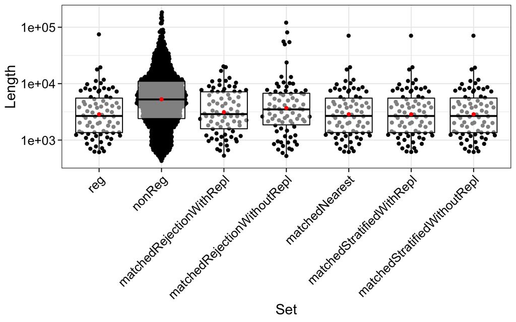

```r
data.frame(set=c(rep("reg", length(regMiniGenes)),
                 rep("nonReg", length(nonRegMiniGenes)),
                 rep("matchedRejectionWithRepl", length(matchedRejectionWithRepl)),
                 rep("matchedRejectionWithoutRepl", length(matchedRejectionWithoutRepl)),
                 rep("matchedNearest", length(matchedNearest)),
                 rep("matchedStratifiedWithRepl", length(matchedStratifiedWithRepl)),
                 rep("matchedStratifiedWithoutRepl", length(matchedStratifiedWithoutRepl))),
           length=c(regMiniGenes$length, nonRegMiniGenes$length, matchedRejectionWithRepl$length, matchedRejectionWithoutRepl$length, matchedNearest$length, matchedStratifiedWithRepl$length, matchedStratifiedWithoutRepl$length)) %>%
    mutate(set=factor(set, levels=c("reg", "nonReg", "matchedRejectionWithRepl", "matchedRejectionWithoutRepl", "matchedNearest", "matchedStratifiedWithRepl", "matchedStratifiedWithoutRepl"))) %>%
    ggplot(., aes(x=set, y=length)) +
        geom_quasirandom() +
        scale_y_log10() +
        geom_boxplot(alpha=.5, outlier.size = -1, col="black") +
        stat_summary(fun.y="mean", geom="point", col="red") +
        labs(x="Set", y="Length") +
        myTheme +
        theme(axis.text.x = element_text(angle=45, vjust=1, hjust=1))
```

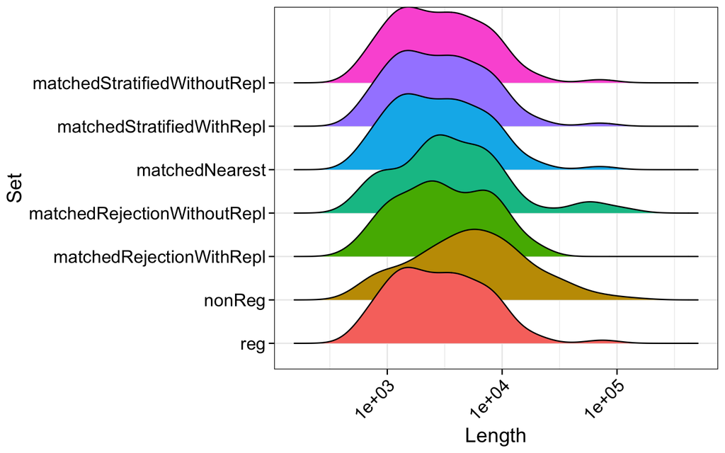

```r
data.frame(set=c(rep("reg", length(regMiniGenes)),
                 rep("nonReg", length(nonRegMiniGenes)),
                 rep("matchedRejectionWithRepl", length(matchedRejectionWithRepl)),
                 rep("matchedRejectionWithoutRepl", length(matchedRejectionWithoutRepl)),
                 rep("matchedNearest", length(matchedNearest)),
                 rep("matchedStratifiedWithRepl", length(matchedStratifiedWithRepl)),
                 rep("matchedStratifiedWithoutRepl", length(matchedStratifiedWithoutRepl))),
           length=c(regMiniGenes$length, nonRegMiniGenes$length, matchedRejectionWithRepl$length, matchedRejectionWithoutRepl$length, matchedNearest$length, matchedStratifiedWithRepl$length, matchedStratifiedWithoutRepl$length)) %>%
    mutate(set=factor(set, levels=c("reg", "nonReg", "matchedRejectionWithRepl", "matchedRejectionWithoutRepl", "matchedNearest", "matchedStratifiedWithRepl", "matchedStratifiedWithoutRepl"))) %>%
    ggplot(., aes(x=length, y=set, fill=set)) +
        ggridges::geom_density_ridges() +
        scale_x_log10() +
        labs(x="Length", y="Set") +
        myTheme +
        theme(axis.text.x = element_text(angle=45, vjust=1, hjust=1))
```

[^1]: [Amemiya et al. 2019](https://www.nature.com/articles/s41598-019-45839-z)
[^2]: [excluderanges package on Bioconductor](http://bioconductor.org/packages/release/data/annotation/html/excluderanges.html)
[^3]: [nullranges package on Bioconductor](https://bioconductor.org/packages/release/bioc/html/nullranges.html)